# 36-315 Lab 04

Your Name Here

Due Saturday, September 25 2021 (12:00pm)

## Lab 04: Histograms, Boxplots, and Density Estimates for Quantitative Data

# Problem 1 (45 points): Histograms and Boxplots

In this problem, we’ll introduce continuous data using the `mtcars` dataset. Below is the code necessary to load in this dataset (i.e., define the `mtcars` variable).

```r
library(datasets)
data(mtcars)
head(mtcars)
```

```
##                    mpg cyl disp  hp drat    wt  qsec vs am gear carb
## Mazda RX4         21.0   6  160 110 3.90 2.620 16.46  0  1    4    4
## Mazda RX4 Wag     21.0   6  160 110 3.90 2.875 17.02  0  1    4    4
## Datsun 710        22.8   4  108  93 3.85 2.320 18.61  1  1    4    1
## Hornet 4 Drive    21.4   6  258 110 3.08 3.215 19.44  1  0    3    1
## Hornet Sportabout 18.7   8  360 175 3.15 3.440 17.02  0  0    3    2
## Valiant           18.1   6  225 105 2.76 3.460 20.22  1  0    3    1
```

The `mtcars` dataset contains mostly continuous variables. Let’s visualize the marginal distributions of several of those continuous variables. First we’ll use histograms, and then we’ll use boxplots.

1. (5pts) Create a histogram showing the marginal distribution of the `mpg` variable. Luckily, the way you make a histogram with `ggplot()` is very similar to the way you make a bar chart with categorical data. To make a histogram, just write `ggplot()` code as if you were making a bar plot, but then replace `geom_bar()` with `geom_histogram()`. Be sure that your graph has appropriate titles/labels, and set `col` and `fill` within `geom_histogram()` equal to colors of your preference. You can ignore any warnings that `R` gives you (we’ll talk about those shortly).

```r
library(tidyverse)
```

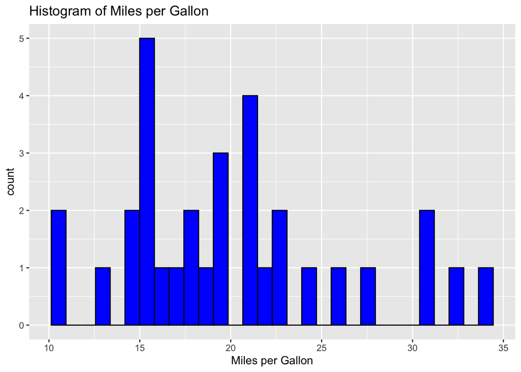

```r
ggplot(mtcars, aes(x = mpg)) + geom_histogram(col = "black", fill = "blue") + labs(title = "Histogram of Miles per Gallon", x = "Miles per Gallon")
```

2. (10pts) When you make a histogram without anything in `geom_histogram()`, `R` still makes the plot, but will deliver this message: “`stat_bin()` using `bins = 30`. Pick better value with `binwidth`.” There are two different arguments you can use within `geom_histogram()`:
- `bins`
- `binwidth`

First, make a histogram of `mpg` with `bins = 4`. Try making `bins` bigger and smaller, and choose a value for `bins` that you like. After you’ve done that, describe in one sentence what the `bins` argument does.

*Here’s a `bins` setting I like:*

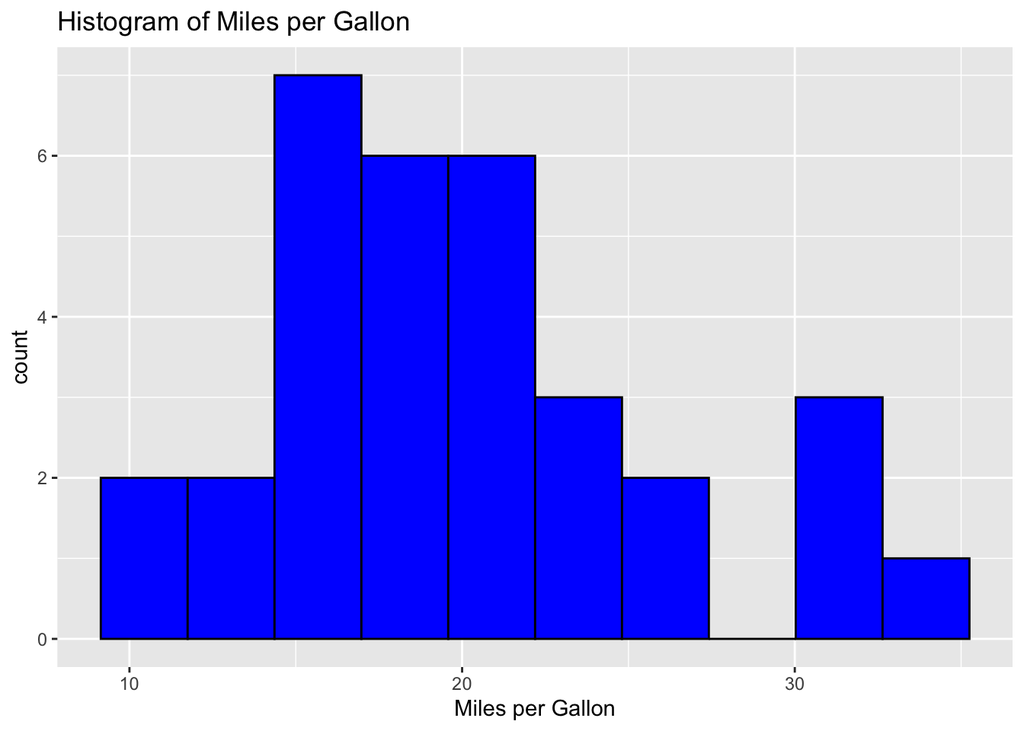

```r
ggplot(mtcars, aes(x = mpg)) + geom_histogram(col = "black", fill = "blue", bins = 10) + labs(title = "Histogram of Miles per Gallon", x = "Miles per Gallon")
```

*The bins argument dictates the number of bars (or bins) that are in the graph. [Notice that even though I specified `bins = 10`, there aren’t 10 bars on the graph; this is because there is an “empty” bar around the 28 mark.]*

After you’ve done that: Similarly, make a histogram of `mpg` with `binwidth = 4`. Try making `binwidth` bigger and smaller, and choose a setting for `binwidth` that you like. After you’ve done that, describe in one sentence what the `binwidth` argument does.

*Here’s a `binwidth` setting I like:*

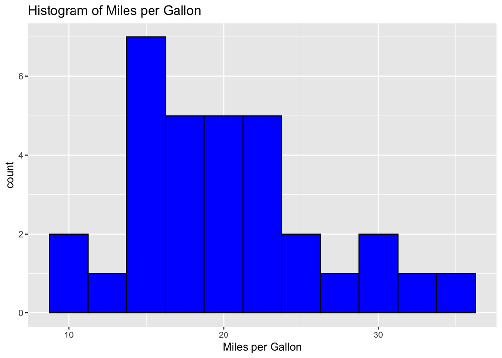

```r
ggplot(mtcars, aes(x = mpg)) + geom_histogram(col = "black", fill = "blue", binwidth = 2.5) + labs(title = "Histogram of Miles per Gallon", x = "Miles per Gallon")
```

*The `binwidth` argument controls how wide the bars are. [Notice that you can specify a `binwidth` less than 1, but you can’t do the same for `bins`.]*

For this part, all you have to do is turn in a histogram with a `bins` setting that you like and a histogram with a `binwidth` setting that you like (as well as a short discussion about what these arguments do).

3. (10 points) Create another histogram of `mpg`, but this time, instead of specifying `bins` or `binwidth`, add the following within `geom_histogram()`: `breaks = seq(10, 35, by = 5), alpha = .2`.

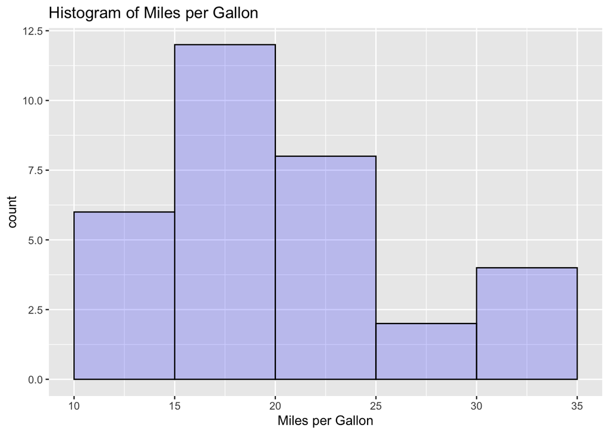

```r
ggplot(mtcars, aes(x = mpg)) + geom_histogram(col = "black", fill = "blue", breaks = seq(10, 35, by = 5), alpha = .2) + labs(title = "Histogram of Miles per Gallon", x = "Miles per Gallon")
```

After you’ve made this new graph, answer the following:

- What did setting `breaks = seq(10, 35, by = 5)` do to the graph?

*This made it so the bars are now constructed to count the number of observations with MPG values within five-mile ranges, from 10 to 35. For instance, the first bar counts the number of vehicles with an MPG between 10 and 15 gallons.*

- Try a few new values of the `alpha` parameter. What are the possible values you can use for `alpha`? What happens when you decrease `alpha`? What happens when you increase `alpha`? (The code you turn in this problem can use any `alpha` you want.)

*The alpha parameter can range from 0 to 1. When you decrease alpha, the shading becomes lighter or more transparent. When you increase alpha, the shading becomes darker or less transparent. The default alpha value is 1.*

4. (10 points) In class we talked about the similarities and differences between histograms and bar plots. In this part, do the following:
- Create a bar plot of `mpg` using `geom_bar()`. Note that you don’t need to specify bins in `geom_bar()`.

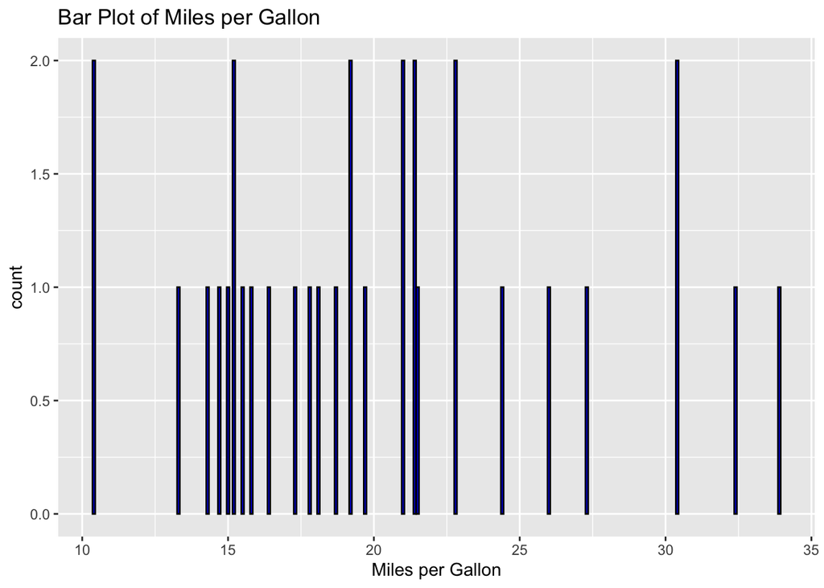

```r
ggplot(mtcars, aes(x = mpg)) + geom_bar(col = "black", fill = "blue") + labs(title = "Bar Plot of Miles per Gallon", x = "Miles per Gallon")
```

- Copy-and-paste your code from Part B, and change `binwidth = 0.1`. This should produce a histogram with a very small binwidth.

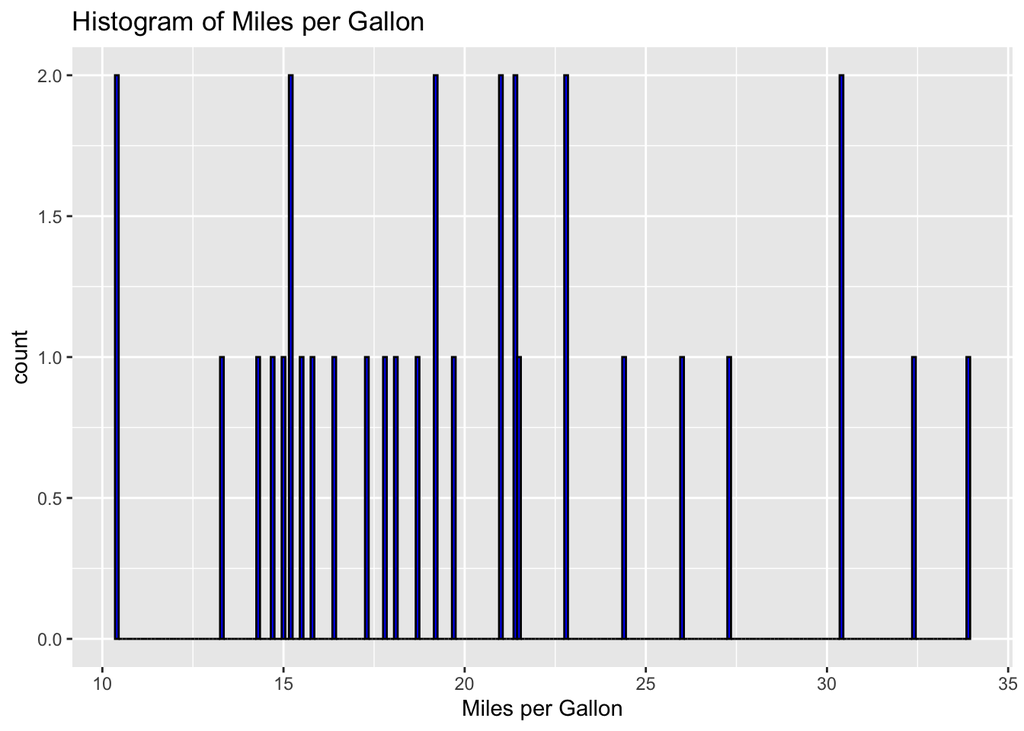

```r
ggplot(mtcars, aes(x = mpg)) + geom_histogram(col = "black", fill = "blue", binwidth = 0.1) + labs(title = "Histogram of Miles per Gallon", x = "Miles per Gallon")
```

- The two plots you just made should look basically the same. Explain why they look the same in 1-2 sentences.

*When we make a barplot, we create a bar for each individual category; when we treat `mpg` as a category, each unique MPG measurement is treated as its own category and gets its own bar. Meanwhile, when we make a histogram with `binwidth = 0.1`, each bar has width 0.1; it turns out that, in this dataset, MPG is measured within 0.1 miles:*

```r
table(mtcars$mpg)
```

```
##
## 10.4 13.3 14.3 14.7   15 15.2 15.5 15.8 16.4 17.3 17.8 18.1 18.7 19.2 19.7   21
##    2    1    1    1    1    2    1    1    1    1    1    1    1    2    1    2
## 21.4 21.5 22.8 24.4   26 27.3 30.4 32.4 33.9
##    2    1    2    1    1    1    2    1    1
```

*Thus, once again, each unique MPG measurement will get its own bar.*

5. (10pts) Luckily, making a boxplot in `ggplot()` is pretty easy too. We used `geom_histogram()` to make histograms, so what function do you think we use to make boxplots? Yep, `geom_boxplot()`. For this part, do the following:
- Make a boxplot of `mpg` by copying-and-pasting your Part C code, and replacing all of the `geom_histogram()` code with `geom_boxplot()`. Set `fill` within `geom_boxplot()` to a color of your choice.

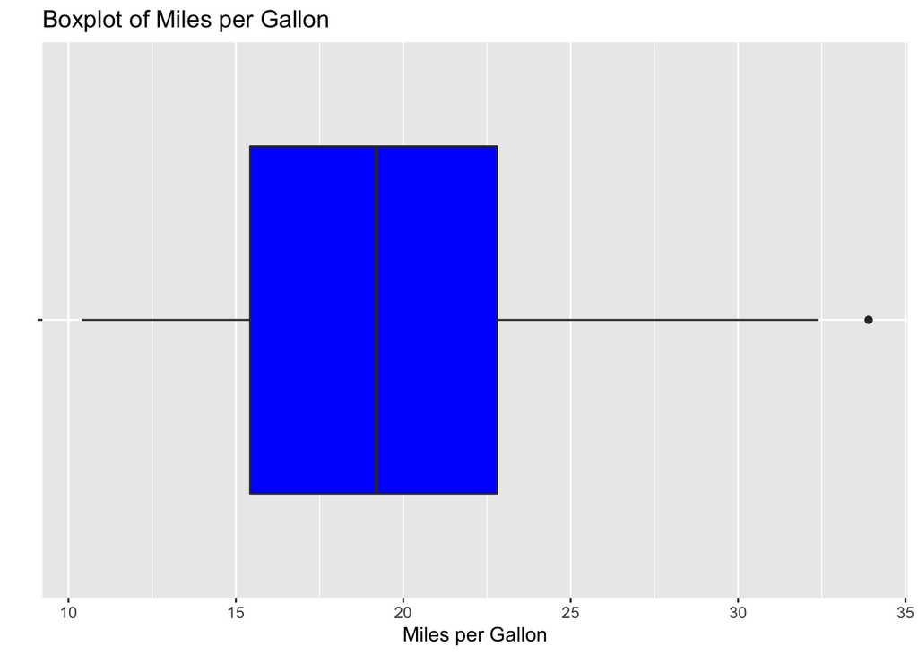

```r
ggplot(mtcars, aes(x = mpg, y = "")) + geom_boxplot(fill = "blue") + labs(title = "Boxplot of Miles per Gallon", x = "Miles per Gallon", y = "")
```

- After you’ve made your boxplot, notice that the y-axis has numbers, but they don’t actually mean anything. To fix this, add `y = ""` within `aes()`, and be sure to add the label `labs(y = "")`.
- Now make a side-by-side boxplot of `mpg`, with one box for each level of `gear`. We’ll treat `gear` as a categorical variable, which only has three categories:

```r
#making gear categorical
mtcars$gear = factor(mtcars$gear)
```

Now copy-and-paste your boxplot code, and set `y` and `fill` equal to `gear`. This should give you a boxplot of `mpg` for each level of `gear`.

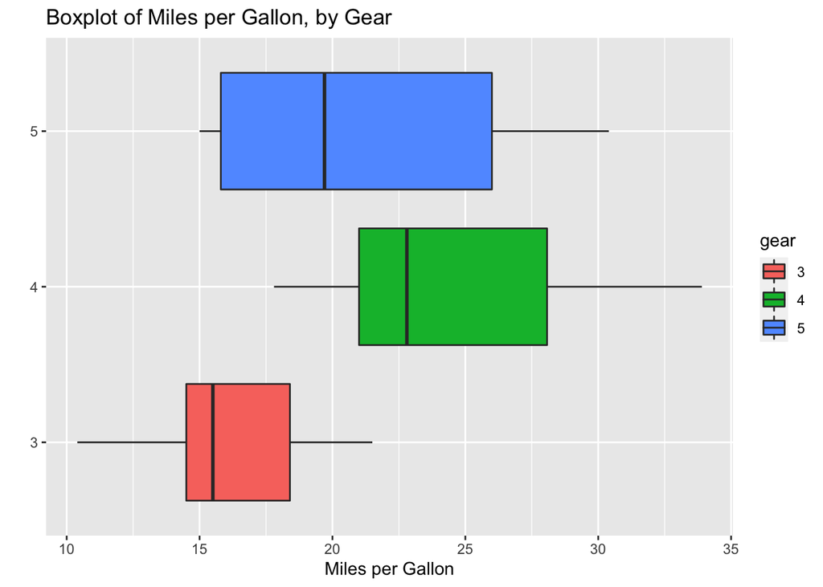

```r
ggplot(mtcars, aes(x = mpg, y = gear)) + geom_boxplot(aes(fill = gear)) + labs(title = "Boxplot of Miles per Gallon, by Gear", x = "Miles per Gallon", y = "")
```

For this part, you just need to turn in two boxplots: One of just `mpg`, and one side-by-side boxplot of `mpg` and `gear`.

# Problem 2: Estimating Continuous Densities (35 points)

We will again work with the `mtcars` dataset in this problem.

1. (5pts) Similar to Question 1A, make a histogram of `mpg`, but on the **density** scale. To do this, simply copy-and-paste your histogram code from Question 1A, and add `aes(y = ..density..)` within `geom_histogram()`. Then, choose a `bins` or `binwidth` you think is most appropriate (similar to Question 1B).

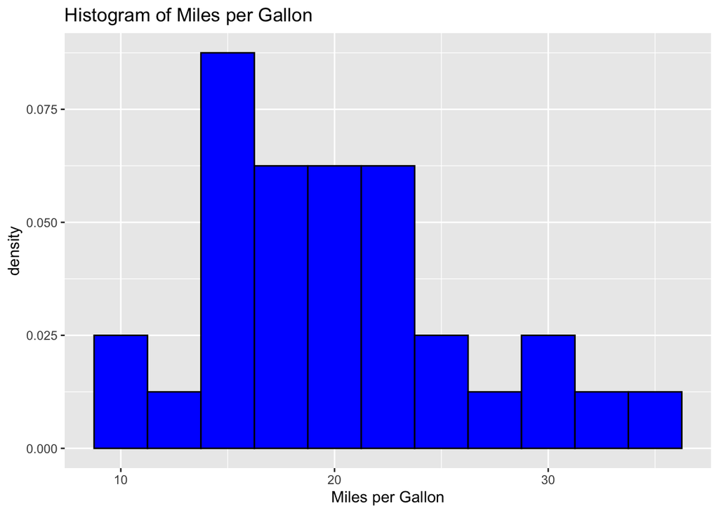

```r
ggplot(mtcars, aes(x = mpg)) + geom_histogram(aes(y = ..density..), col = "black", fill = "blue", binwidth = 2.5) + labs(title = "Histogram of Miles per Gallon", x = "Miles per Gallon")
```

2. (10pts) Now we will take the histogram you made in Part A and add a couple of more components to it. Do the following:
- Overlay a density estimate on top of your histogram. To do this, add `+ geom_density()` in your `ggplot` code.
- Add a “rug” to your plot by adding `+ geom_rug()` to your code. A “rug plot” shows where individual values occur just below the x-axis. Rug plots are often helpful when we’re working with small datasets, where histograms and density estimates often over- or under-smooth the data.

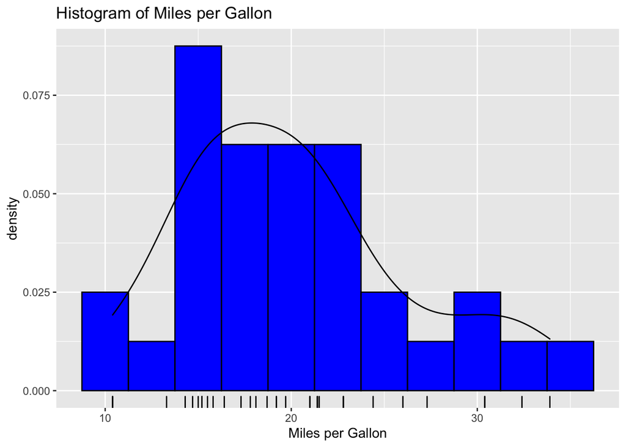

```r
ggplot(mtcars, aes(x = mpg)) + geom_histogram(aes(y = ..density..), col = "black", fill = "blue", binwidth = 2.5) + geom_density() + geom_rug() + labs(title = "Histogram of Miles per Gallon", x = "Miles per Gallon")
```

Your final plot should have both a smoothed density and rug added to it.

3. (10pts) Recreate the graph in Part B, but this time, change the `adjust` argument within the `geom_density()` function. Try a few different values, such as 1/10, 1/2, 1, 2, 10. What happens as we reduce the `adjust` parameter? What happens as we increase the `adjust` parameter? Pick a value that you think best displays the distribution of `mpg`; only include that version of the graph in your output for this part.

*As we reduce the `adjust` parameter, the bandwidth of the density decreases, and the density more closely fits the exact input data. As we increase the adjust parameter, the bandwidth of the density increases, and the density smooths over the input data more.*

*If you read the help documentation for `geom_density()`, you’ll find that `adjust` is a multiplier for the bandwidth automatically estimated in `R`. For example, this plot uses a bandwidth that’s 75% of the estimated bandwidth:*

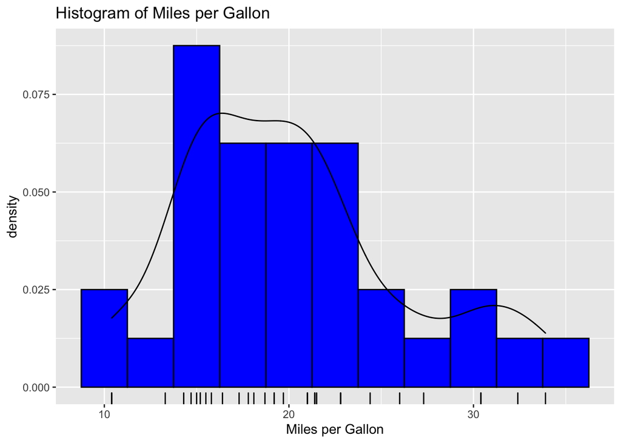

```r
ggplot(mtcars, aes(x = mpg)) + geom_histogram(aes(y = ..density..), col = "black", fill = "blue", binwidth = 2.5) + geom_density(adjust = 0.75) + geom_rug() + labs(title = "Histogram of Miles per Gallon", x = "Miles per Gallon")
```

4. (10pts) On the homework, we’ll explore adding parametric Normal densities to a histogram instead of nonparametric densities. For this part, we’ll explore a statistical test that allows us to formally assess if a variable seems to follow a certain distribution: The Kolmogorov-Smirnov (KS) test.

```r
ks.test(x = mtcars$mpg, y = "pnorm", mean = mean(mtcars$mpg), sd = sd(mtcars$mpg))
```

```
##
##  One-sample Kolmogorov-Smirnov test
##
## data:  mtcars$mpg
## D = 0.1263, p-value = 0.687
## alternative hypothesis: two-sided
```

**Note**: The KS test is known to have low statistical power. We’ll talk about this nuance next week.

*We see that the p-value is 0.687; thus, we fail to reject the null hypothesis that the `mpg` variable is Normally distributed. This may seem odd, because looking at the above histogram, the variable doesn’t look that Normally distributed. This is likely a power issue - we have a small sample size, which leads to low statistical power, and the KS test itself also has low power. As mentioned above, we’ll talk about this in depth next week.*

# Problem 3: Histograms and Density Plots for Conditional Distributions (20 points)

The upcoming homework will focus on the distribution of a quantitative variable (such as `mpg`) conditional on a categorical variable (such as `gear`). In this problem, we explore different plots that visualize the conditional distribution of `mpg` given `gear`.

1. (5 points) For this part we’ll create a *stacked histogram*, which is very similar to a stacked bar plot. Follow these steps to make a stacked histogram of `mpg` (stacked by `gear`):
- Create a histogram of `mpg` the typical way, using `ggplot()` and `geom_histogram()`. Choose a `bins` or `binwidth` you think is most appropriate.
- Within `aes()`, set `fill = gear`.

Note that, in the stacked histogram, the counts are *stacked on top of each other*. For this part, all you have to do is include the stacked histogram.

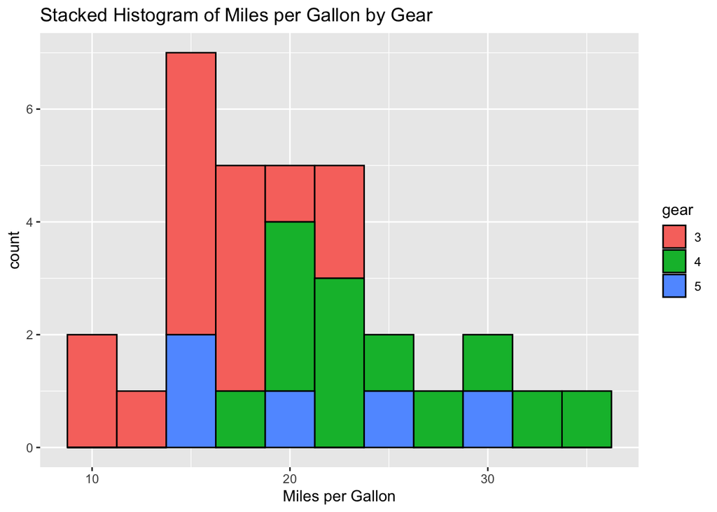

```r
ggplot(mtcars, aes(x = mpg, fill = gear)) + geom_histogram(color = "black", binwidth = 2.5) + labs(title = "Stacked Histogram of Miles per Gallon by Gear", x = "Miles per Gallon")
```

2. (5 points) The stacked histogram in Part A *technically* shows the conditional distribution `mpg` given `gear`, but it’s difficult to see. The reason is that the bars for each `gear` don’t all start at the x-axis. It can be helpful to instead make transparent histograms. To do this, copy-and-paste your code from Part A, and then specify `alpha = 0.5, position = "identity"` within `geom_histogram()`. Note that the default value of the `position` parameter is `"stack"`. For this part, all you need to do is turn in your plot.

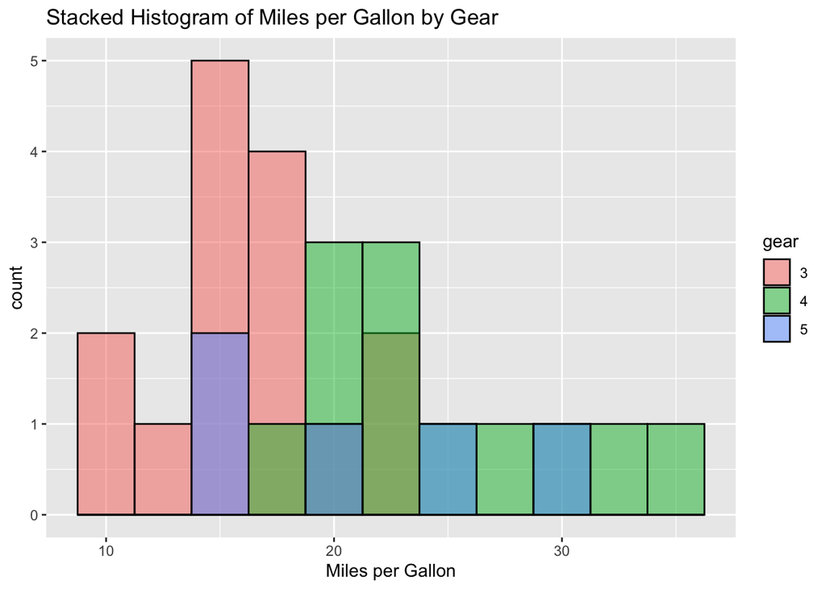

```r
ggplot(mtcars, aes(x = mpg, fill = gear)) + geom_histogram(color = "black", binwidth = 2.5, alpha = 0.5, position = "identity") + labs(title = "Stacked Histogram of Miles per Gallon by Gear", x = "Miles per Gallon")
```

3. (5 points) Now we’ll use a conditional density plot to visualize the conditional distribution of `mpg` given `gear`. To do this, follow these steps:
- Copy-and-paste your code from Part A.
- Change your `geom_histogram()` code to `geom_density(alpha = 0.5)`.

Feel free to change the `adjust` or `alpha` parameters to your liking in order to better display the conditional distributions. Note that *not* setting an `alpha` value makes it almost impossible to see the different distributions (try this out in the Console).

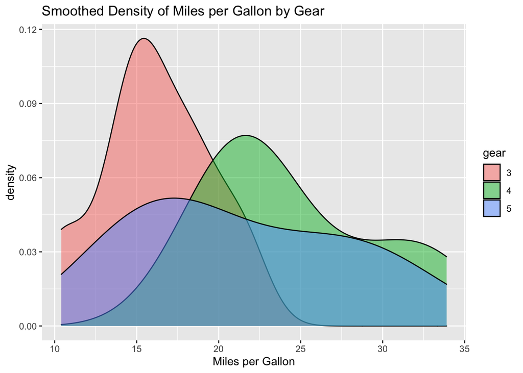

```r
ggplot(mtcars, aes(x = mpg, fill = gear)) + geom_density(alpha = 0.5) + labs(title = "Smoothed Density of Miles per Gallon by Gear", x = "Miles per Gallon")
```

4. (5 points) Now copy-and-paste your code in Part C, but replace `fill = gear` with `color = gear`. What changed?

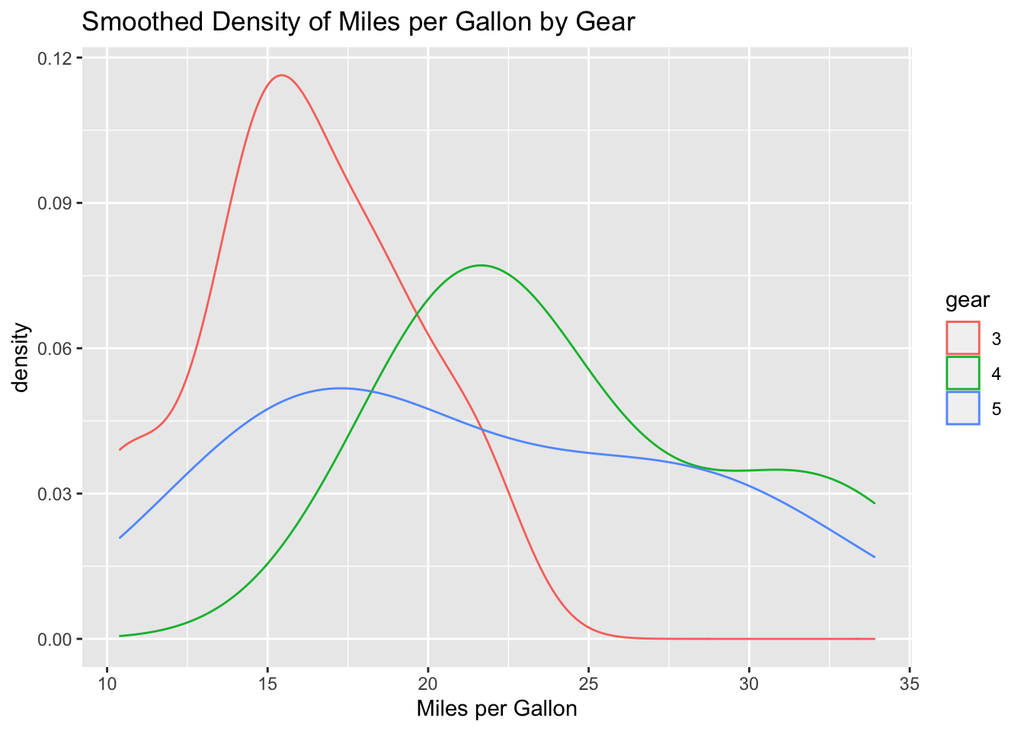

```r
ggplot(mtcars, aes(x = mpg, color = gear)) + geom_density(alpha = 0.5) + labs(title = "Smoothed Density of Miles per Gallon by Gear", x = "Miles per Gallon")
```

*The densities are instead outlined in different colors, rather than “filled” by different colors.*